# Delay Report

September 17, 2024

# Delay Report for Dengue

There were 5992 enrollees diagnosed with Dengue.

The diagnostic opportunity window (i.e., time period before diagnosis where diagnostic opportunities may occur) was set between 1 and 30 days before diagnosis.

### Visit Trends

The following is a plot of all patient visits and SSD-related visits that occurred in the 180 days prior to the index Dengue diagnosis.

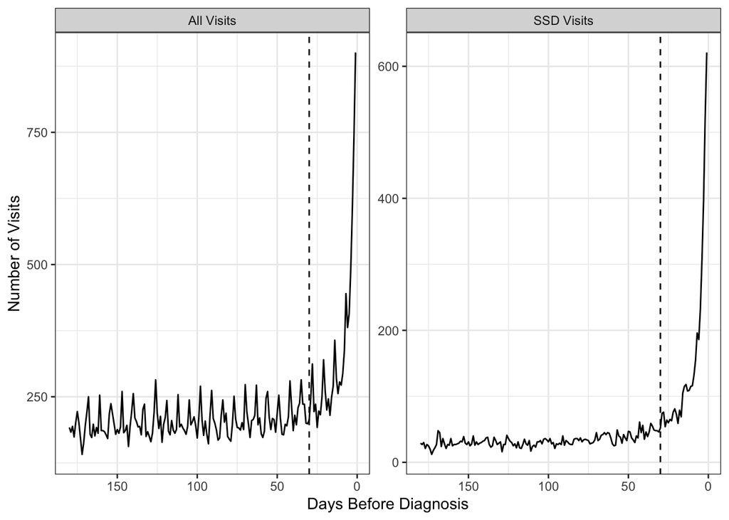

## SSD Visit Results

### Expected Visit Trends

The following figure depicts the estimated trends in the number of expected visit counts (red line) for SSD-related visits compared to the observed number (black line). The dashed line represents the start of the diagnostic opportunity window. Plots are presented using linear, quadratic, cubic and exponential models to fit the expected number of SSD-related visits each day before the diagnostic opportunity window.

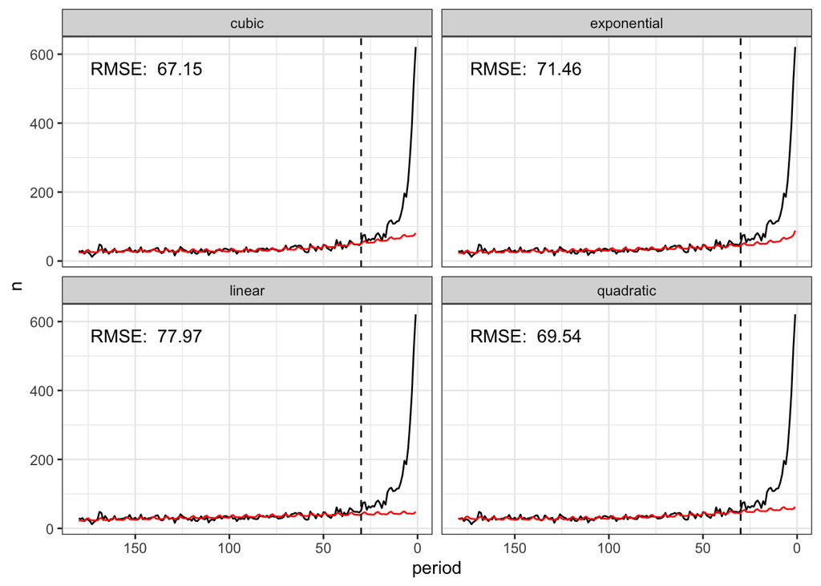

The following table summarizes the observed and expected number of visits and the estimated number of missed opportunities using each of the four different models plotted above:

| model | Total Visits | Expected Visits | Number Missed |
| --- | --- | --- | --- |
| cubic | 4423 | 1855 | 2568 |
| exponential | 4423 | 1652 | 2771 |
| linear | 4423 | 1263 | 3160 |
| quadratic | 4423 | 1549 | 2874 |

The following plot describes the estimated number of missed opportunities each day before the index diagnosis using each of the four models described above:

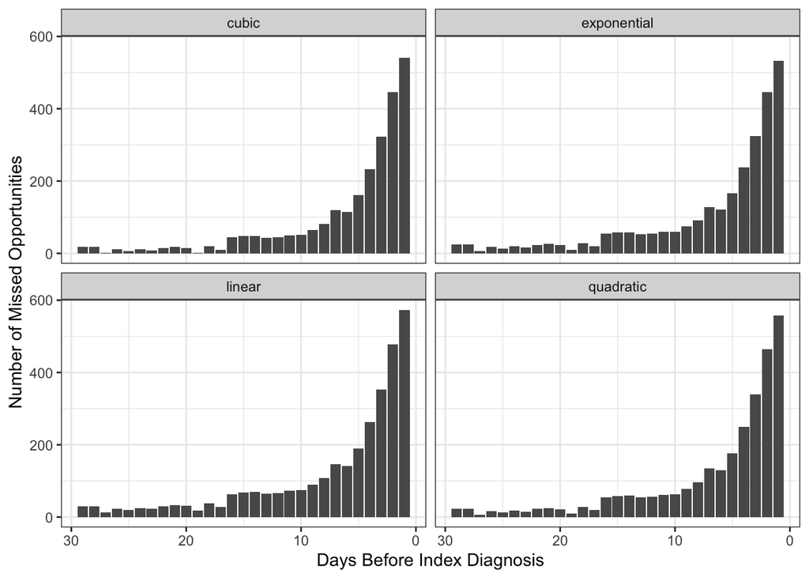

The final selected model (based on model fit prior to the diagnostic opportunity window) was the cubic model with an estimated number of missed opportunities of 2568

### Bootstrapping Results

The following section summarizes results of the bootstrapping analysis where the individual specific visits representing a diagnostic delay were repeatedly sampled. A total of 1000 trials were run for this analysis (100 outer bootstraps and 10 trials inside each bootstrap sample)

The following figure depicts the observed (black lines) and estimated expected (red lines) number of SSD visits each day before the index diagnosis across bootstap samples:

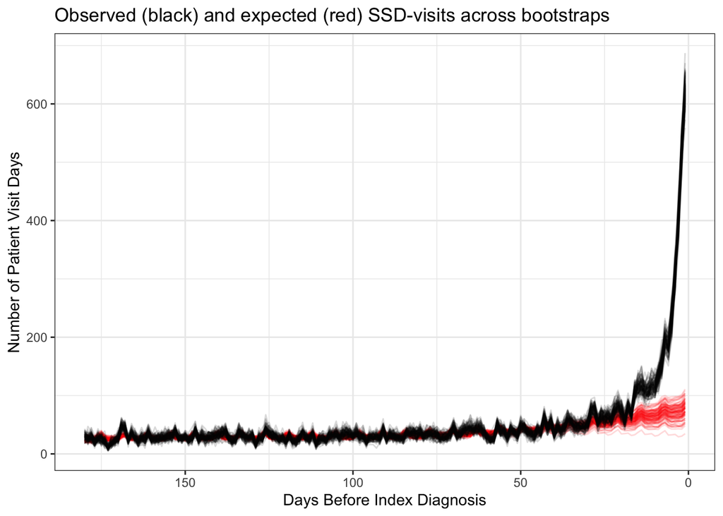

The following figure depicts the estimated number of SSD visits representing a missed opportunity each day before the index diagnosis across bootstap samples:

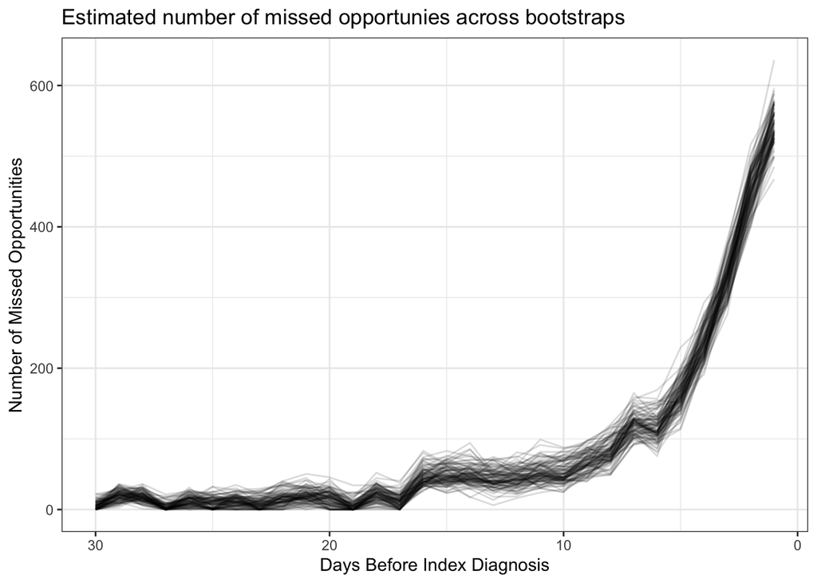

The following table is an overall summary of the frequency and duration of missed opportunities:

| Measure | Value |
| --- | --- |
| Number of Patients Missed | 1635.22 (1478.95-1800) |
| Percent of Patients Missed | 27.29 (24.68-30.04) |
| Mean Duration of Delays (Days) | 6.27 (5.3-7.32) |
| Median Duration of Delays (Days) | 3.52 (3-4) |
| Mean Number of Misses per patient delayed | 1.61 (1.48-1.76) |
| Median Number of Misses per patient delayed | 1 (1-1) |